[figure not shown]

# **Decoding Hand Signs: An ASL Classification Journey**

### **What is ASL? A Journey into a Language of Movement**

**Have you ever spoken with your hands?** *Not just a wave or thumbs-up, but a whole conversation filled with gestures, expressions, and fluid motion? That's the essence of American Sign Language (ASL).*

**More than just letters:** *ASL isn't simply finger-spelling the English alphabet. It's a rich visual language with its own unique grammar, vocabulary, and even facial expressions!*

**Think in 3D:** *Imagine your signing space as a canvas. The movement, shape, and placement of your hands all carry meaning. ASL isn't linear, it's multidimensional!*

**A world of stories, emotions, and ideas:** *ASL is how a vibrant community connects, shares experiences, and passes down cultural knowledge. It's a language to laugh in, debate in, and even dream in.*

### **Our Quest**

*To build the most proficient American Sign Language (ASL) image classifier, capable of deciphering hand signs with both speed and accuracy. This quest is driven by the potential to unlock powerful tools for communication and learning within the deaf and hard-of-hearing community.*

### **Why it Matters**

**Bridging Communication Gaps:** *Imagine a world where a real-time ASL translator removes language barriers, fostering seamless interactions and understanding.*

**Celebrating a Rich Language:** *By building a technology that 'understands' ASL, we implicitly acknowledge and elevate the beauty and complexity of this visual language.*

### **Acknowledgements**

- Dataset
  - Title: The American Sign Language (ASL) Dataset
  - Source: Kaggle
  - Link: https://www.kaggle.com/datasets/prathumarikeri/american-sign-language-09az
  - Acknowledgement: A sincere thank you to Prathum Arikeri, Khaled Jedoui, a Stanford researcher, for assembling and sharing this valuable resource, which is foundational to my research.
- Reference Code
  1. Sign Language EDA (100% Accuracy) Notebook
     - Author: blamerx
     - Link: https://www.kaggle.com/code/blamerx/sign-language-eda-100-acc/notebook
     - Acknowledgement: We are grateful to blamerx for their insightful notebook, which provided inspiration and guidance during the exploratory data analysis phase.
  2. ASL (100% Accuracy) Notebook
     - Author: vexxingbanana
     - Link: https://www.kaggle.com/code/vexxingbanana/asl-100-acc
     - Acknowledgement: Thank you to vexxingbanana for their work. Their notebook offered valuable modeling baselines and helped me explore different approaches.

### **Weapons of Choice**

- **InceptionResNetV2** :
  - Why it's suited for the task: With its depth and hybrid Inception modules, InceptionResNetV2 can learn intricate patterns. This is crucial when dealing with a large and nuanced dataset like our ASL collection.
  - Handling Complexity: Think of it like a detective with many specialized tools – each Inception module examines the image from a different angle, allowing the network to make sense of complex handshapes and gestures.
- **Convolutional NN** :
  - Finding the Fundamentals: CNNs are masters at identifying basic visual features, like edges and shapes. This forms the foundation for understanding the hand formations essential in ASL.
  - Efficient Backbone: When dealing with big datasets, CNNs offer a relatively computationally efficient way to extract those vital building blocks for sign recognition.

## ___Let's start building models___

## **EDA**

1. Importing required libraries

```python
import os
import os

import matplotlib.pyplot as plt
import numpy as np
import pandas as pd
import seaborn as sns
import tensorflow as tf
from keras import Sequential
from keras import layers
from keras.layers import Dense, Conv2D, MaxPooling2D, Flatten

gpus = tf.config.experimental.list_physical_devices('GPU')
for gpu in gpus:
    tf.config.experimental.set_memory_growth(gpu, True)

tf.config.list_physical_devices('GPU')
```

```
[PhysicalDevice(name='/physical_device:GPU:0', device_type='GPU')]
```

2. **Loading the data from directory.**

```python
base_path = './archive/American/'
classes = os.listdir(base_path)
filepaths = []
labels = []
for d in classes:
    flist = os.listdir(base_path + d)
    for f in flist:
        fpath = os.path.join(base_path + d + '/' + f)
        filepaths.append(fpath)
        labels.append(d)
print ('filepaths: ', len(filepaths), '   labels: ', len(labels))
```

```
filepaths:  142261    labels:  142261
```

```python
Fseries=pd.Series(filepaths, name='file_paths')
Lseries=pd.Series(labels, name='labels')
df=pd.concat([Fseries,Lseries], axis=1)
df=pd.DataFrame(np.array(df).reshape(142261,2), columns = ['file_paths', 'labels'])
```

3. **Visualizing Distribution of Data**

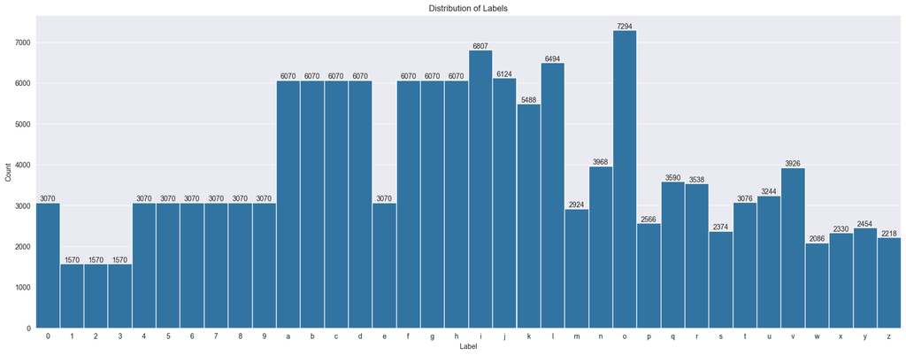

```python
def plot_countplt(title):
    plt.figure(figsize=(22,8))
    sns.set_style("darkgrid")

    ax =sns.countplot(data=df,x='labels',width=1)

    plt.xlabel('Label')
    plt.ylabel('Count')
    plt.title(title)

    for p in ax.patches:
        height = p.get_height()
        plt.text(y=height  + 1,
                x = p.get_x() + p.get_width()/2,
                s='{:1.0f}'.format(height),
                ha='center', va='bottom')

plot_countplt("Distribution of Labels")
```

**Insight**

The dataset exhibits a significant class imbalance, with certain ASL signs appearing much more frequently than others. For example, the sign for the letter 'o' is overrepresented with 7294 samples compared to signs like 'w' or 'z' having far fewer.

This imbalance can cause machine learning models to become biased towards the overrepresented classes. If not addressed, the model may perform well on frequent signs but struggle to accurately recognize less common ones.

4. **Balancing Dataset**

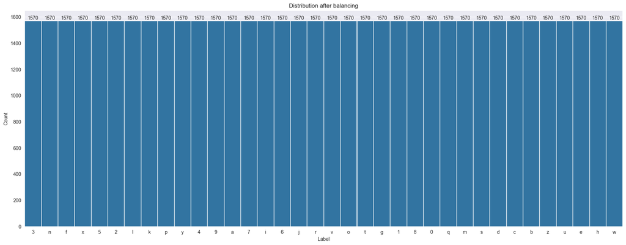

```python
file_count = 1570
samples = []
for category in df['labels'].unique():
    category_slice = df.query("labels == @category")
    samples.append(category_slice.sample(file_count, replace=False,random_state=1))
df = pd.concat(samples, axis=0).sample(frac=1.0, random_state=1).reset_index(drop=True)

plot_countplt("Distribution after balancing")
```

5. **Visualization**

Rendering some random images with respective labels

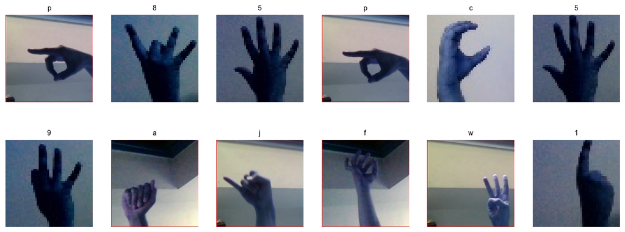

```python
import cv2

plt.figure(figsize=(16,6))
for i in range(12):
    random = np.random.randint(1,len(df))
    plt.subplot(2,6,i+1)
    plt.imshow(cv2.imread(df.loc[random,"file_paths"]))
    plt.title(df.loc[random, "labels"], size = 10, color = "black")
    plt.xticks([])
    plt.yticks([])

plt.show()
```

6. **Splitting the Data into Train Test Split**

```python
from sklearn.model_selection import train_test_split

train_df, test_df = train_test_split(df, train_size=0.95, random_state=0)
train_df, valid_df = train_test_split(train_df, train_size=0.9, random_state=0)
```

7. **Image Data Generator**

We've set up image generators to streamline how our ASL classifier will handle the image data. First, we've included a preprocessing step specifically tailored for the InceptionResNetV2 model we're using. Next, we've added some clever data augmentation – zooming, rotating, and shifting images slightly during training. This helps make our dataset seem larger and prevents the model from getting too comfortable with any specific image orientation. Finally, the generators will neatly pull the images and their corresponding labels from our dataframes, making sure our model is fed a steady stream of data during training, validation, and testing.

```python
IMAGE_SIZE = 200
BATCH_SIZE = 8
```

```python
from tensorflow.keras.preprocessing.image import ImageDataGenerator

image_generator = ImageDataGenerator(
        preprocessing_function=tf.keras.applications.inception_resnet_v2.preprocess_input,
        zoom_range=0.15,
        rotation_range=30,
        height_shift_range=0.1,
        width_shift_range=0.1
        )


train_generator = image_generator.flow_from_dataframe(
    train_df,
    target_size=(IMAGE_SIZE, IMAGE_SIZE),
    batch_size=BATCH_SIZE,
    class_mode='categorical',  # since we  have multiple classes
    colormode="rgb",
    x_col='file_paths', y_col='labels',
)

validation_generator = image_generator.flow_from_dataframe(
    valid_df,
    target_size=(IMAGE_SIZE, IMAGE_SIZE),
    batch_size=BATCH_SIZE,
    class_mode='categorical',  # since we  have multiple classes
    colormode="rgb",
    x_col='file_paths', y_col='labels',
)
```

```
Found 48324 validated image filenames belonging to 36 classes.
Found 5370 validated image filenames belonging to 36 classes.
```

```python
test_generator = image_generator.flow_from_dataframe(
    test_df,
    target_size=(IMAGE_SIZE, IMAGE_SIZE),
    batch_size=BATCH_SIZE,
    class_mode='categorical',  # since we  have multiple classes
    colormode="rgb",
    x_col='file_paths', y_col='labels',
)
```

```
Found 2826 validated image filenames belonging to 36 classes.
```

## **Training Models**

8. **Building InceptionResNetV2 Model**

Importing InceptionResNetV2 base model from keras

```python
base_model = tf.keras.applications.InceptionResNetV2(include_top=False, input_shape=(IMAGE_SIZE,IMAGE_SIZE,3))
```

Adding top layers

```python
no_classes = 36

model = tf.keras.Sequential([
    base_model,
    tf.keras.layers.GlobalAveragePooling2D(),
    tf.keras.layers.Dense(128, activation='relu'),
    tf.keras.layers.BatchNormalization(),
    tf.keras.layers.Dropout(0.2),
    tf.keras.layers.Dense(no_classes, activation='softmax')
])
```

```python
model.compile(loss='categorical_crossentropy', optimizer="adam", metrics=['accuracy'])
```

```python
model.summary()
```

[output not shown]

```python
patience = 1
stop_patience = 3
factor = 0.5

callbacks = [
    tf.keras.callbacks.ModelCheckpoint("resnet.h5", save_best_only=True, verbose = 0),
    tf.keras.callbacks.EarlyStopping(patience=stop_patience, monitor='val_loss', verbose=1),
    tf.keras.callbacks.ReduceLROnPlateau(monitor='val_loss', factor=factor, patience=patience, verbose=1)
]
```

```python
epochs = 10
# history = model.fit(train_generator, validation_data=validation_generator, epochs=epochs, callbacks=callbacks, verbose=1)
```

- Saving history Object for later referencing

```python
import pickle

with open('/restnet_trainHistoryDict', 'wb') as file_pi:
    pickle.dump(history.history, file_pi)
```

```python
def plot_accuracy_loss(history):
    fig, (ax1, ax2) = plt.subplots(nrows=1, ncols=2, figsize=(10, 4))
    fig.suptitle("Accuracy & Loss")
    ax1.plot(history['accuracy'], color='teal', label='accuracy')
    ax1.plot(history['val_accuracy'], color='orange', label='val_accuracy')
    ax1.set_title('Accuracy', fontsize=20)
    ax1.set_xlabel("Epochs")
    ax1.legend(loc="lower right")

    ax2.plot(history['loss'], color='teal', label='loss')
    ax2.plot(history['val_loss'], color='orange', label='val_loss')
    ax2.set_title('Loss', fontsize=20)
    ax2.set_xlabel("Epochs")
    ax2.legend(loc="upper right")
    fig.tight_layout()
    plt.show()
```

```python
with open('/restnet_trainHistoryDict', "rb") as file_pi:
    hist = pickle.load(file_pi)
    plot_accuracy_loss(hist)
```

[output not shown]

9. **Convolutional NN Model**

Building model

```python
def build_cnn():
    model = Sequential()
    model.add(Conv2D(75, (3, 3), strides=1, padding='same', activation='relu', input_shape=(IMAGE_SIZE, IMAGE_SIZE, 3)))
    model.add(tf.keras.layers.BatchNormalization())
    model.add(MaxPooling2D((2, 2), strides=2, padding='same'))
    model.add(Conv2D(50, (3, 3), strides=1, padding='same', activation='relu'))
    model.add(tf.keras.layers.Dropout(0.2))
    model.add(tf.keras.layers.BatchNormalization())
    model.add(MaxPooling2D((2, 2), strides=2, padding='same'))
    model.add(Conv2D(25, (3, 3), strides=1, padding='same', activation='relu'))
    model.add(tf.keras.layers.BatchNormalization())
    model.add(MaxPooling2D((2, 2), strides=2, padding='same'))
    model.add(Flatten())
    model.add(Dense(units=512, activation='relu'))
    model.add(tf.keras.layers.Dropout(0.3))
    model.add(Dense(units=36, activation='softmax'))

    model.compile(optimizer='SGD', loss='categorical_crossentropy', metrics=['accuracy'])
    model.summary()
    return model
```

```python
patience = 1
stop_patience = 3
factor = 0.5

cnn_callbacks = [
    tf.keras.callbacks.ModelCheckpoint("cnn_model.h5", save_best_only=True, verbose = 0),
    tf.keras.callbacks.EarlyStopping(patience=stop_patience, monitor='val_loss', verbose=1),
    tf.keras.callbacks.ReduceLROnPlateau(monitor='val_loss', factor=factor, patience=patience, verbose=1)
]
```

```python
cnn_model = build_cnn()
```

[output not shown]

Training Model

```python
hist_cnn = cnn_model.fit(train_generator,validation_data=validation_generator, epochs=10,callbacks=cnn_callbacks)
```

```python
import pickle

with open('/cnn_trainHistoryDict', 'wb') as file_pi:
    pickle.dump(hist_cnn.history, file_pi)
```

```python
with open('/cnn_trainHistoryDict', "rb") as file_pi:
    hist = pickle.load(file_pi)
    plot_accuracy_loss(hist)
```

[output not shown]

## **Evaluation**

9. Loading saved models

```python
from tensorflow.keras.models import load_model

resnet = load_model('resnet.h5')
cnn = load_model('cnn_model.h5')
```

10. Evaluating InceptionResNetV2

```python
resnet.evaluate(test_generator)
```

```
[0.006253672298043966, 0.9971691370010376]
```

11. Evaluating CNN

```python
cnn.evaluate(test_generator)
```

```
[0.07304392009973526, 0.9752299785614014]
```

```python
from sklearn.metrics import classification_report

#resnet
resnet_predictions = resnet.predict(test_generator)
y_resnet_pred = np.argmax(resnet_predictions, axis=1)
y_resnet_true = test_generator.classes

#cnn
cnn_predictions = cnn.predict(test_generator)
y_cnn_pred = np.argmax(cnn_predictions, axis=1)
y_cnn_true = test_generator.classes


class_mapping = train_generator.class_indices
class_names = list(class_mapping.keys())

print(class_names)
```

```
['0', '1', '2', '3', '4', '5', '6', '7', '8', '9', 'a', 'b', 'c', 'd', 'e', 'f', 'g', 'h', 'i', 'j', 'k', 'l', 'm', 'n', 'o', 'p', 'q', 'r', 's', 't', 'u', 'v', 'w', 'x', 'y', 'z']
```

Classification Report for InceptionResNetV2

```python
print(classification_report(y_resnet_true, y_resnet_pred, target_names=class_names))
```

[output not shown]

Classification Report for CNN

```python
print(classification_report(y_cnn_true, y_cnn_pred, target_names=class_names))
```

[output not shown]